# Exercise 2: Rejection sampling

Nikola Sekulovski

2021-10-29

# Introduction

In this exercise I will try to illustrate how *rejection sampling* works, using the `AR` package. Rejection sampling is the underlying way with which we obtain random values from specific probability distributions when using regular random generation functions such as `rnorm`, `runif`, etc. The interested reader is refereed to this [YouTube video](https://www.youtube.com/watch?v=kYWHfgkRc9s&t=491s&ab_channel=BenLambert) by [Ben Lambert](https://www.youtube.com/channel/UC3tFZR3eL1bDY8CqZDOQh-w) for more details.

# Getting started

First we load the required package(s).

```r
library(AR)
```

# Illustration using the `AR` package:

Set the number of simulations that we will use to 3000 throughout the different examples.

```r
nsim <- 3000
```

## Example 1: Sampling a `standard normal` from a `standard normal` proposal.

Here we want to sample from (approximate) a `standard normal distribution` $x_i \sim N(\mu = 0, \sigma = 1)$, using the same *proposal* distribution ($y_i$). I am using this example to illustrate that if we sample from the same distribution i.e., if we use a so-called *proposal* distribution of the same form as the *target* distribution then we would have a *Rejection ratio* equal to zero.

```r
set.seed(123)
sim_1 = AR.Sim(n = nsim,
               f_X = function(y){dnorm(y, mean = 0, sd = 1, log = FALSE)},
               Y.dist = "norm", Y.dist.par = c(0,1),
               Rej.Num = TRUE,
               Rej.Rate = TRUE,
               Acc.Rate = FALSE
)
```

```
## Optimal c = 1
```

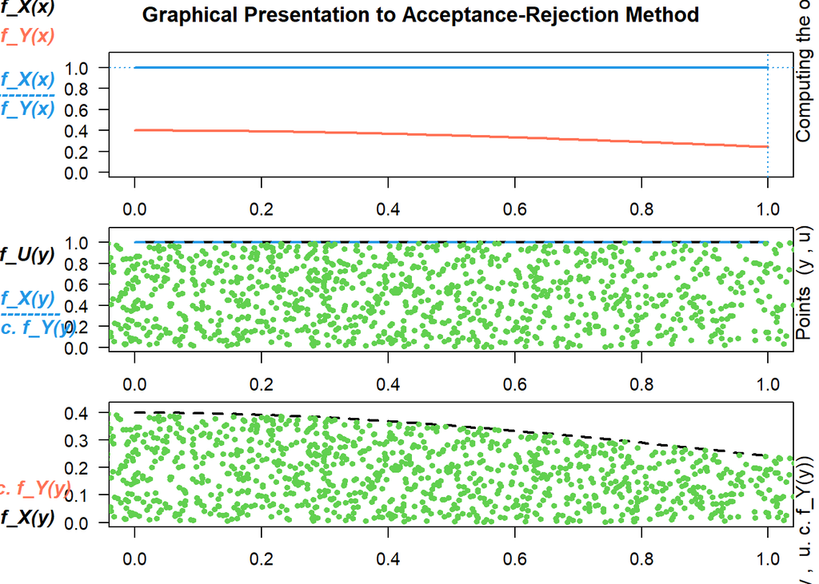

Accepted (green) vs. Rejected (red) values

```
## The numbers of Rejections = 0
## Ratio of Rejections = 0
```

As we can clearly see, both from the the output and the graph, all generated values fall within the specified distribution. This is due to sampling from the a proposal distrubution of the same form as the target distribution, and hence the *rejection ratio* is zero.

## Example 2: Sampling an `exponential` from a `uniform` proposal.

In this second illustration I am going to repeat the example given by the [above mentioned video](https://www.youtube.com/watch?v=kYWHfgkRc9s&t=491s&ab_channel=BenLambert). Basically, we try to approximate a $x_i \sim Exp(1)$ by sampling from a $y_i\sim U(0,8)$ proposal.

```r
set.seed(123)
sim_2 = AR.Sim(n = nsim,
               f_X = function(y){dexp(y, rate = 1, log = FALSE)},
               Y.dist = "unif", Y.dist.par = c(0,8),
               Rej.Num = TRUE,
               Rej.Rate = TRUE,
               Acc.Rate = FALSE
)
```

```
## Optimal c = 7.999
```

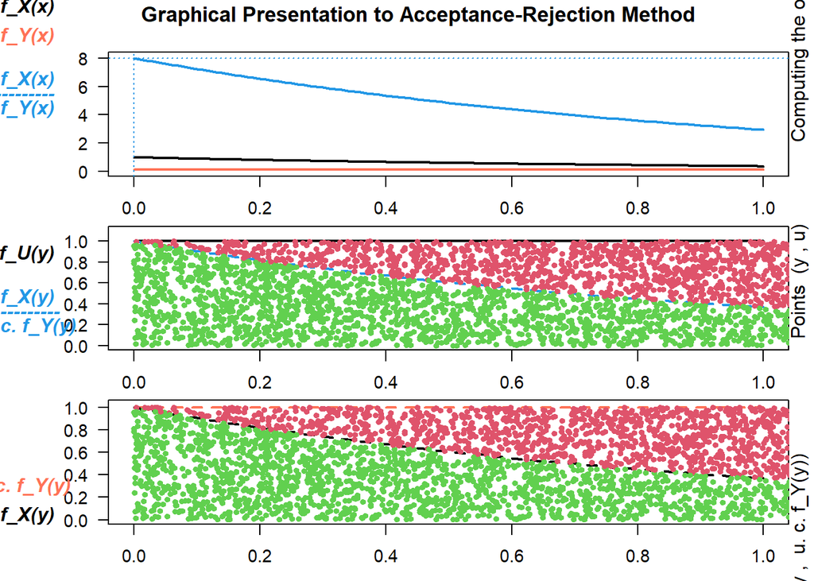

Accepted (green) vs. Rejected (red) values

```
## The numbers of Rejections = 20656
## Ratio of Rejections = 0.873
```

We can clearly see that the *rejection rate* is very high in this example (0.87), and also the graph is very similar to the one presented in the video.

# Conclusion

*Rejection sampling* is one of the most basic algorithms used to sample from a particular probability distribution. As it is clearly illustrated above, it is not very efficient when we are sampling from a *proposal* distribution that is very different from the *target* distribution and vice versa. However, asymptotically, it is always guaranteed that an approximation of the *target* distribution will be reached, the only open question is the efficiency.

# Random seed

If we try to repeat one of the examples above using a different random seed, then we will find that the exact values drawn will differ from seed to seed:

```r
set.seed(789)
sim_3 = AR.Sim(n = nsim,
               f_X = function(y){dnorm(y, mean = 0, sd = 1, log = FALSE)},
               Y.dist = "norm", Y.dist.par = c(0,1),
               Rej.Num = TRUE,
               Rej.Rate = TRUE,
               Acc.Rate = FALSE
)
```

```
## Optimal c = 1
```

```
## The numbers of Rejections = 0
## Ratio of Rejections = 0
```

```r
compare_1 <- data.frame(sim_1, sim_3)

compare_1[1:10, ]
```

```
##         sim_1       sim_3
## 1   0.8005543 -1.31951278
## 2   1.5587083 -0.01967972
## 3   1.2394959 -0.97104037
## 4   1.7150650 -0.48448399
## 5   0.1830826 -0.08568832
## 6  -0.6868529 -1.01095967
## 7   1.6901844 -1.22010267
## 8   0.3598138 -1.00278032
## 9   0.5490967  0.04350280
## 10 -0.5558411  0.92790739
```

And if we repeat the simulation with the same random seed, we will obtain exactly the *same* values.

```r
set.seed(789)
sim_4 = AR.Sim(n = nsim,
               f_X = function(y){dnorm(y, mean = 0, sd = 1, log = FALSE)},
               Y.dist = "norm", Y.dist.par = c(0,1),
               Rej.Num = TRUE,
               Rej.Rate = TRUE,
               Acc.Rate = FALSE
)
```

```
## Optimal c = 1
```

```
## The numbers of Rejections = 0
## Ratio of Rejections = 0
```

```r
compare_2 <- data.frame(sim_3, sim_4)

compare_2[1:10, ]
```

```
##          sim_3       sim_4
## 1  -1.31951278 -1.31951278
## 2  -0.01967972 -0.01967972
## 3  -0.97104037 -0.97104037
## 4  -0.48448399 -0.48448399
## 5  -0.08568832 -0.08568832
## 6  -1.01095967 -1.01095967
## 7  -1.22010267 -1.22010267
## 8  -1.00278032 -1.00278032
## 9   0.04350280  0.04350280
## 10  0.92790739  0.92790739
```

Voilà!

END OF DOCUMENT